# A Bayesian Hidden Markov Model Approach to Portfolio Resampling

Ian Frankenburg

In this brief case study, I apply my Bayesian Hidden Markov Model (HMM) implementation to an all-ETF portfolio allocation problem. I propose a novel resampling approach based upon the posterior predictive distribution of asset weights, arrived at through mean-variance optimization. This case study was inspired through reading [1], where a Bayesian resampling approach to portfolio allocation was shown to outperform purely Monte Carlo-based resampling. The Bayesian HMM resampling framework provides a coherent paradigm for incorporating both parameter estimation uncertainty and market regime uncertainty into the mean-variance optimization process. This is in contrast with the “certainty equivalence” principal of standard mean-variance optimization, whereby “plug-in” parameter estimates are used in the optimization routine which can lead to badly-leveraged portfolio weights due the inherent uncertainties involved in the estimation process [2].

To start, I’ll download weekly return data for a basket of five ETFs:

1. S&P 500
2. EFA – a non-US equities fund
3. IJS – a small-cap value fund
4. EEM – an emerging-markets fund
5. AGG – a fixed income bond fund.

```r
symbols <- c("SPY","EFA", "IJS", "EEM","AGG")

prices <- getSymbols(symbols, src = 'yahoo', from = "2005-01-01",
             auto.assign = TRUE, warnings = FALSE) %>%
  map(~Ad(get(.))) %>%
  reduce(merge) %>%
  `colnames<-`(symbols)

prices_monthly <- to.weekly(prices, indexAt = "last", OHLC = FALSE)
asset_returns_xts <- na.omit(Return.calculate(prices_monthly, method = "log"))
```

I’ll visualize the collection of log-returns over time as follows

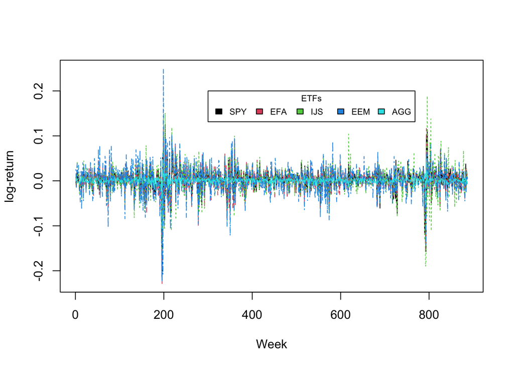

```r
matplot(asset_returns_xts, type="l", ylab="log-return", xlab="Week")
legend(300,.2,legend = symbols,fill = 1:length(symbols),title = "ETFs", cex=.7, horiz = T)
```

A portfolio then consists of a weighted collection of these five ETFs. To reframe the problem formally, I seek to solve the optimization problem
$$\begin{aligned}
\min_{\omega} & & \omega^\top\Sigma_{T+\tau}\omega \\
\text{subject to} & &\omega^\top\mu_{T+\tau}\geq\mu^{\star}\\
\text{and} & & \omega^\top1 = 1.
\end{aligned}
\qquad\qquad(1)$$
In words, this implies minimizing portfolio variance while ensuring returns of some level $\mu^\star$. It can be shown through Lagrange multipliers [4] that for a given return level $\mu^\star$, the optimal $\omega$ is given as

$$\omega=\Sigma_{T+\tau}^{-1}\Big[\frac{\mu^{\star}(1^\top\Sigma_{T+\tau}^{-1}1)\mu_{T+\tau}-(\mu_{T+\tau}^\top\Sigma_{T+\tau}^{-1}1)\mu_{T+\tau}+(\mu_{T+\tau}^\top\Sigma_{T+\tau}^{-1}\mu_{T+\tau})1-\mu^\star(\mu_{T+\tau}^\top\Sigma_{T+\tau}^{-1}1)1}{(\mu_{T+\tau}^\top\Sigma_{T+\tau}^{-1}\mu_{T+\tau})(1^\top\Sigma_{T+\tau}^{-1}1)-(\mu_{T+\tau}^\top\Sigma_{T+\tau}^{-1}1)^2}\Big]$$

To address where the Hidden Markov Modeling comes into play, for simplicity, I’ll assume two separate market regimes that determine the parameter estimates for $\mu_{T+\tau}$ and $\Sigma_{T+\tau}$. I’ll call these market states VOL-ON and VOL-OFF. This Markov Chain can be visualized as

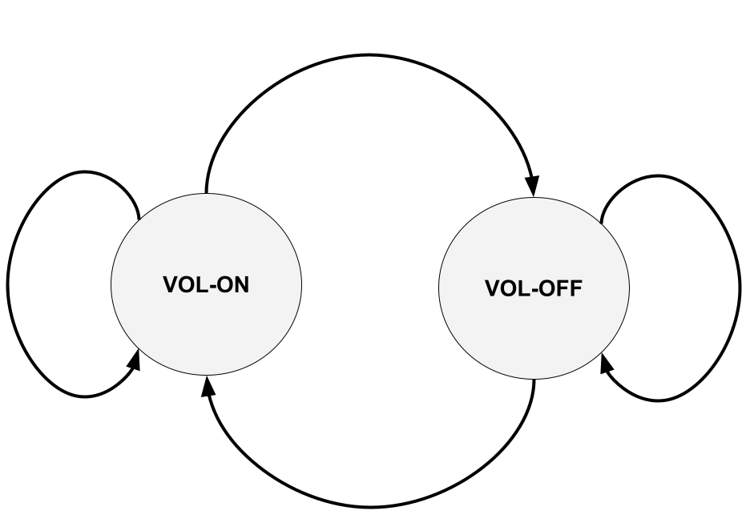

This very simple Markov chain defines a hidden dynamical system, of which my HMM implementation learns the structure, along with the parameters governing the Gaussian sampling distributions. I’ll employ the posterior predictive distribution of the fitted HMM to obtain a probability distribution for plausible portfolio weights $\omega$ for the yet unrealized time period $T+\tau$. I’ll also use draws from the posterior $p(\Theta|r_{1:T})$ to get estimates of $\Sigma_{T+\tau}$ and $\mu_{T+\tau}$ while accounting for estimation uncertainty and market regime uncertainty. Sampling from the posterior predictive distribution is algorithmically straightforward through Monte Carlo analysis as follows:

1. Draw $\Theta^{(s)}, S_{1:T}^{(s)}\sim p(\Theta, S_{1:T}|r_{1:T})$
2. Draw $S_{T+\tau}^{(s)}\sim p(S_{T+\tau}|S_T^{(s)}, \Theta^{(s)})$
3. Solve (1) to draw from $\omega^{(s)}_{T+\tau}\sim p(\omega_{T+\tau}|r_{1:T},\Theta^{(s)}, S_{T+\tau}^{(s)},\mu^\star)$ for a given $\mu^\star$
4. Repeat 1-3 to form a collection of iid random draws from predictive density $p(\omega_{T+\tau}|r_{1:T}, \mu^\star)$

I’ll write a short try-catch function call in R that calls the requisite C++ HMM code. This is useful because (rarely) a numerical error will occur in the sampling and result in a singular $\Sigma_{S_t}$ draw.

```r
sampler = function(y, niter, burnin, mu0, Sigma0, v0, S0, m, nugget){
  r <- NULL
  attempt <- 1
  while( is.null(r) && attempt <= 3 ) {
    attempt <- attempt + 1
    try(
       r <- gibbs(niter = niter, burnin = burnin,
                      y=y, Sigma0=Sigma00, v0=v0, mu0=mu0, S0=S0, h=1, nugget, m)
    )
  }
  return(r)
}
```

Once the HMM is fit, I can visualize the distinct market regime probabilities as a sanity check. One regime is colored in red, the other black.

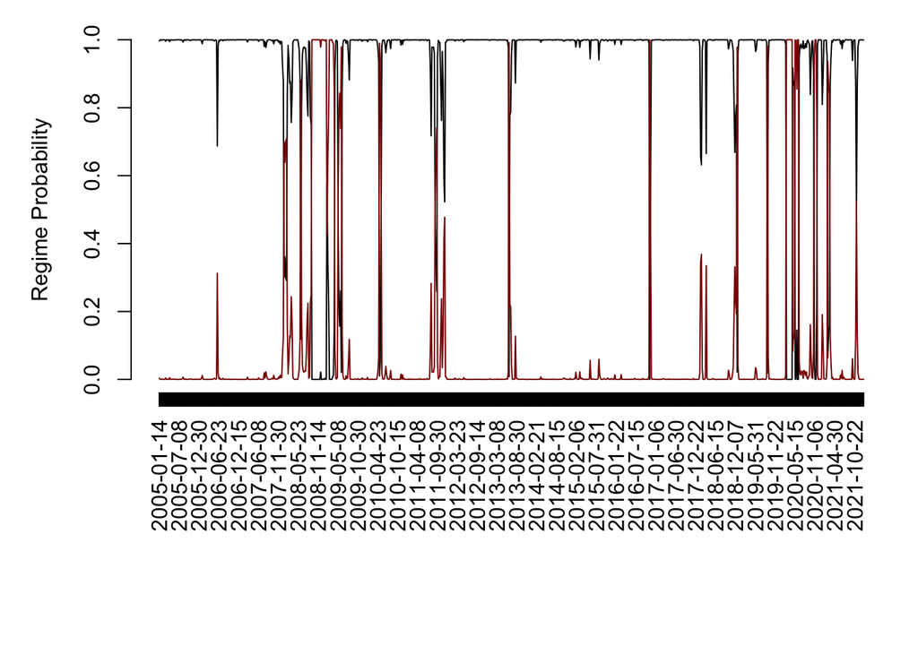

I can also investigate how the correlation structure changes with market regime.

Changing Correlation Structure

| SPY | EFA | IJS | EEM | AGG |
| --- | --- | --- | --- | --- |
| 1.00 | 0.93 | 0.90 | 0.85 | 0.48 |
| 0.93 | 1.00 | 0.87 | 0.90 | 0.52 |
| 0.90 | 0.87 | 1.00 | 0.79 | 0.30 |
| 0.85 | 0.90 | 0.79 | 1.00 | 0.37 |
| 0.48 | 0.52 | 0.30 | 0.37 | 1.00 |

| SPY | EFA | IJS | EEM | AGG |
| --- | --- | --- | --- | --- |
| 1.00 | 0.85 | 0.86 | 0.76 | -0.27 |
| 0.85 | 1.00 | 0.76 | 0.84 | -0.23 |
| 0.86 | 0.76 | 1.00 | 0.70 | -0.29 |
| 0.76 | 0.84 | 0.70 | 1.00 | -0.18 |
| -0.27 | -0.23 | -0.29 | -0.18 | 1.00 |

The following figures show the distribution for each element of $\omega$ for differing levels of $\mu^\star$. Intuitively, it generally appears that as a higher return is desired, the uncertainty about the optimal portfolio weight increases. However it’s peculiar that the posterior for the $\color{green}{\textbf{green}}$ return level is most contracted!

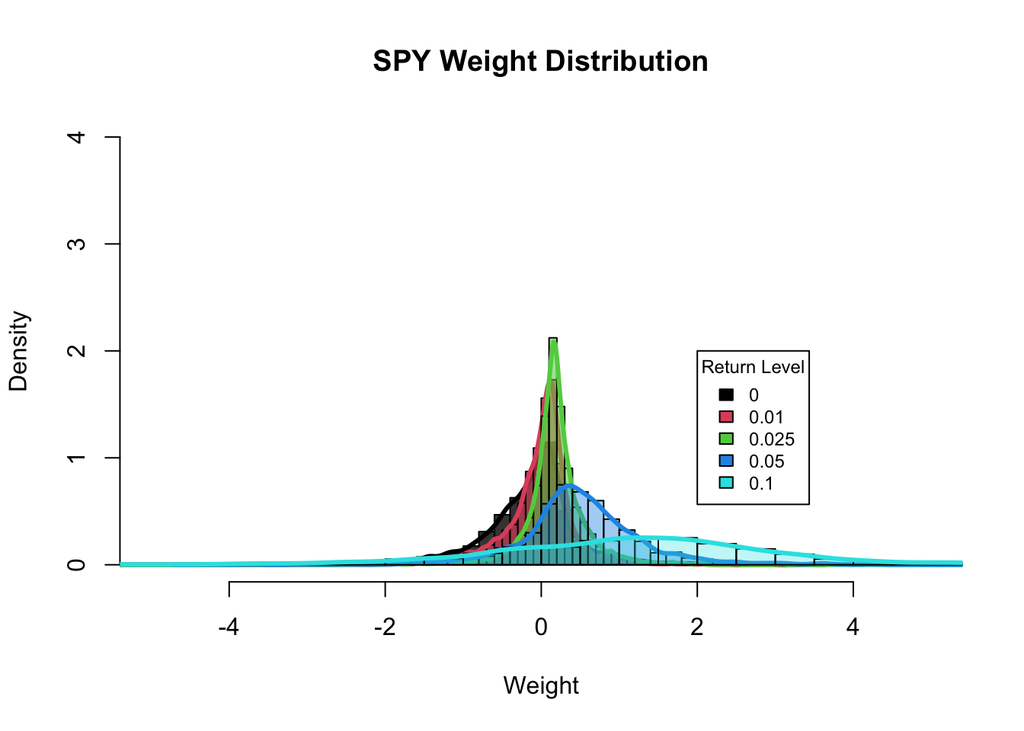

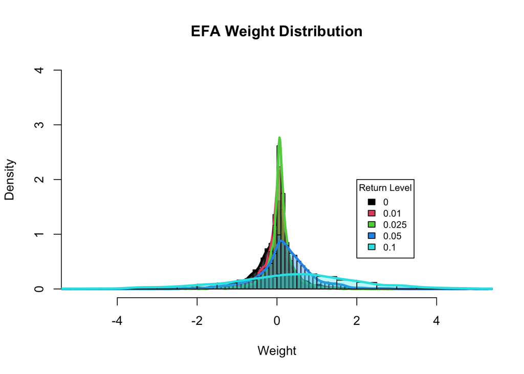

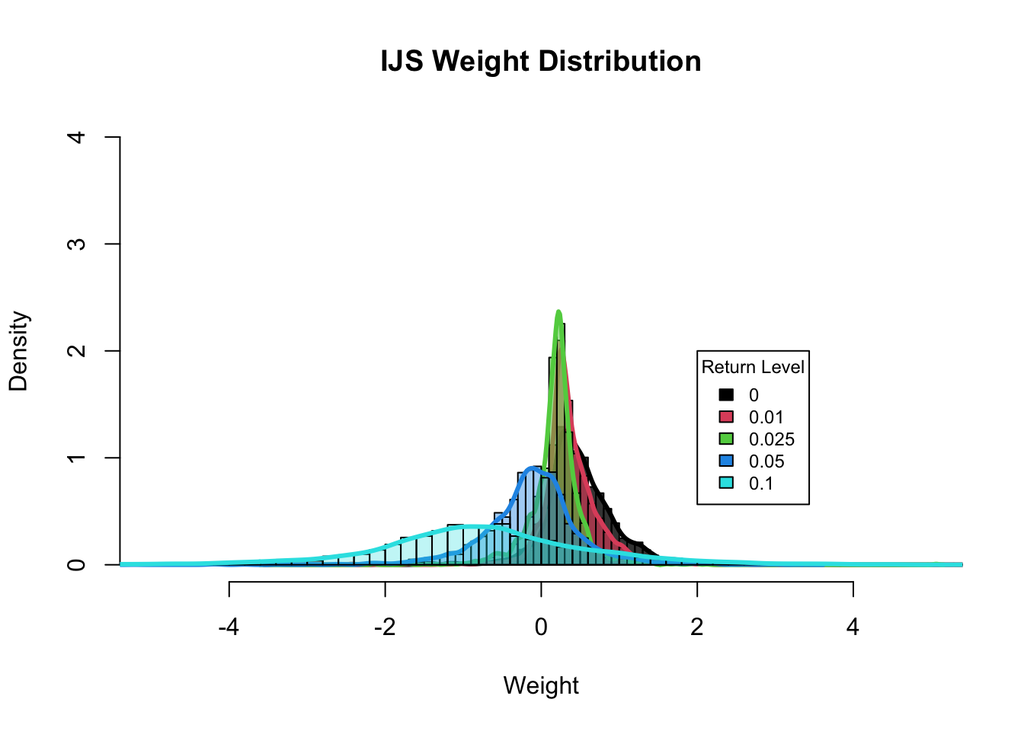

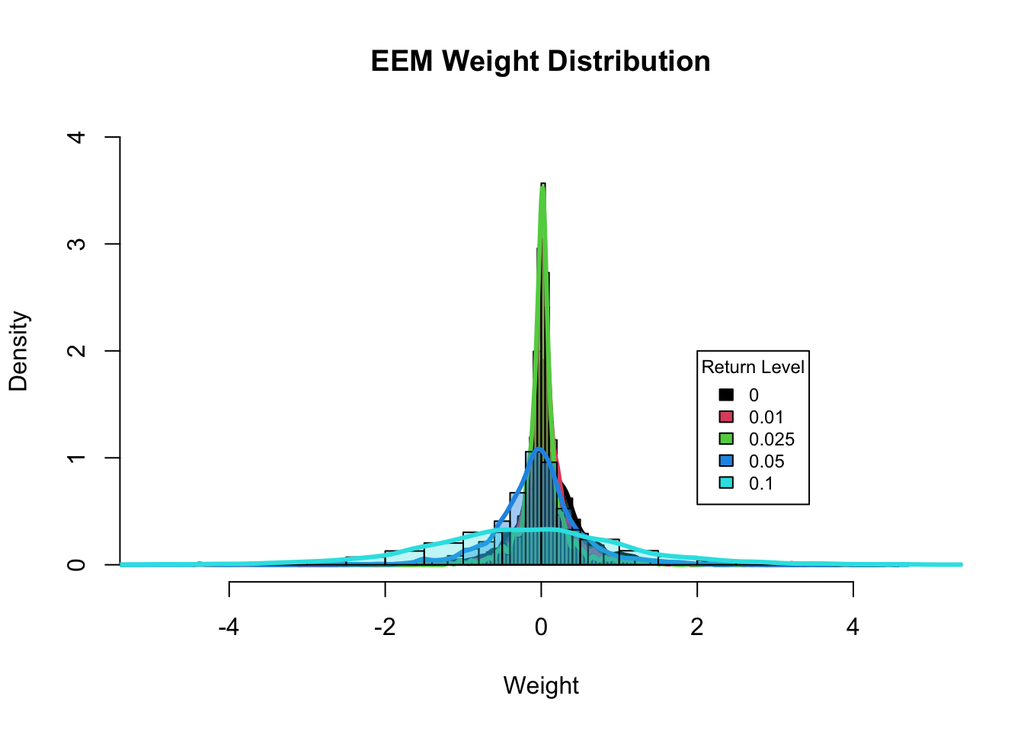

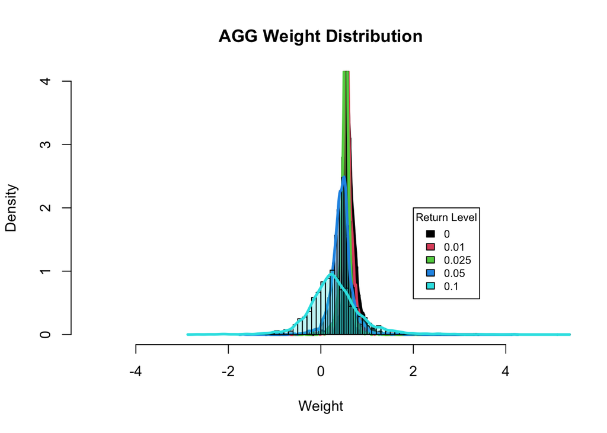

Additionally, through this predictive density on $p(\omega_{T+\tau}|r_{1:T})$, I can obtain distributions for performance metrics such as, e.g., the Sharpe Ratio. Draws from this distribution $p(SR|r_{1:T})$ can be computed through
$$SR^{(s)}:=\frac{\omega_{T+\tau}^{(s)\top}\mu_{T+\tau}^{(s)}}{\sqrt{\omega_{T+\tau}^{(s)\top}\Sigma_{T+\tau}^{(s)}\omega_{T+\tau}^{(s)}}}.$$

Finally, the efficient frontier distribution can now be traced out for given values of $\mu^\star$ by computing the portfolio risk $\sqrt{\omega_{T+\tau}^{(s)\top}\Sigma_{T+\tau}\omega_{T+\tau}^{(s)}}$ for a given sample $\omega_{T+\tau}^{(s)}$ from $p(\omega_{T+\tau}|r_{1:T}, \mu^\star)$. Below displays the mean and median of a resampled frontier. Since the mean is larger than the median, this implies a right-skewness and tail risk involved in the weighting process.

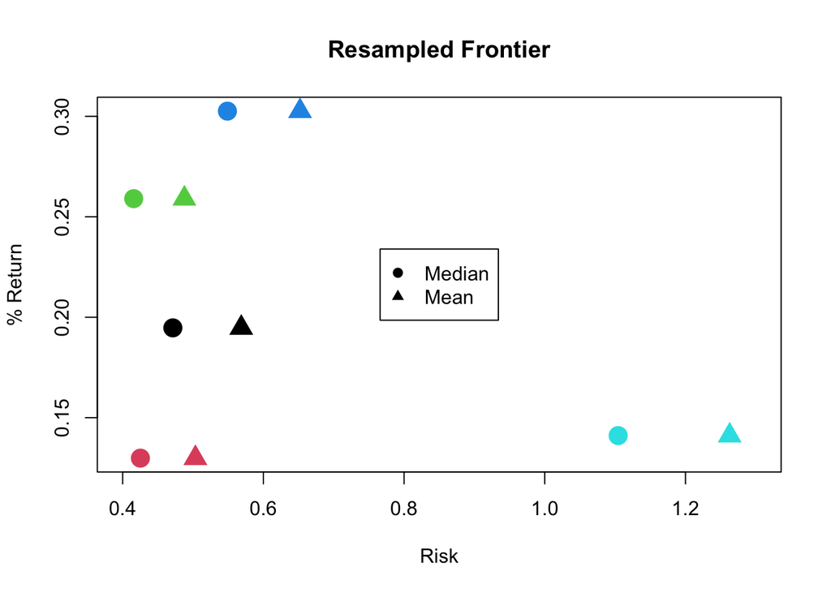

Again, it’s apparent the desirable portfolio corresponds to $\color{green}{\textbf{green}}$ weighting.

# References

- [1] [*Bayes vs. Resampling: A Rematch*](https://faculty.fuqua.duke.edu/~charvey/Research/Published_Papers/P95_Bayes_vs_Markowitz.pdf) - Harvey, Liechtyb and Liechtyc
- [2] [*Bayesian Methods in Finance*](https://www.wiley.com/en-us/Bayesian+Methods+in+Finance-p-9780470249246) - Rachev, Hsu, Bagasheva, and Fabozzi.
- [3] [*Finite Mixture and Markov Switching Models*](https://link.springer.com/content/pdf/10.1007%2F978-0-387-35768-3.pdf) - Sylvia Fruhwirth-Schnatter.
- [4] [*Bayesian Inference of State Space Models: Kalman Filtering and Beyond*](https://link.springer.com/book/10.1007/978-3-030-76124-0) - Kostas Triantafyllopoulos